# COVIDMINDER Example Notebook:

DAR Fall 2020

John S. Erickson

09/01/2020

## INTRODUCTION

This R Notebook and its related R scripts provide a very basic introduction to the **COVIDMINDER** application, which you can find at:

- Public “production” version: https://covidminder.idea.rpi.edu/

The github repository for all the code required for this notebook, including a snapshot of the **COVIDMINDER** application, can be found at:

- https://github.com/TheRensselaerIDEA/COVID-Notebooks

The **COVIDMINDER** github repository can be found at:

- https://github.com/TheRensselaerIDEA/COVIDMINDER

**NOTE:** To contribute or submit to these repositories you must have a github.com ID and must send it to John Erickson at `erickj4@rpi.edu`. **PLEASE DO THIS IMMEDIATELY BEFORE READING ANY FURTHER!!**

## DARL Assignment: CLONING A NOTEBOOK AND UPDATING THE REPOSITORY

In this assignment we’re asking you to…

- clone the `COVID-Notebook` github repository…
- create a personal branch using git, and…
- make additions to the repository by creating a new, customized notebook.

The instructions which follow explain how to accomplish this.

**For DAR Fall 2020** you *must* be using RStudio Server on the IDEA Cluster. Instructions for accessing “The Cluster” appear at the end of this notebook. Don’t forget to send your github ID to `erickj4@rpi.edu`

The recommended procedure for cloning and using this repository is as follows:

- Access the RPI network via VPN
  - See https://itssc.rpi.edu/hc/en-us/articles/360008783172-VPN-Connection-and-Installation for information
- Access RStudio Server on the IDEA Cluster at http://lp01.idea.rpi.edu/rstudio-ose/
  - You must be on the RPI VPN!!
- Access the Linux shell on the IDEA Cluster by clicking the **Terminal** tab of RStudio Server. `cd` into your home (login) directory using: `cd ~`
  - Advanced users may use `ssh` to directly access the Linux shell
- `git clone https://github.com/TheRensselaerIDEA/COVIDMINDER.git` in your `home` directory, resulting in a new directory `COVIDMINDER`
- In the Linux shell, `cd` to `COVIDMINDER/DAL-2020-Notebooks`
- In the Linux shell, `git checkout -b hacl-yourrcs` where `yourrcs` is your RCS id
  - For example, if your RCS is `erickj4`, your new branch should be `hacl-erickj4`
  - It is critical that you include your RCS id in your branch id
- In the RStudio Server UI, navigate to the `COVIDMINDER/DARL-2020-Notebooks` directory via the **Files** panel
  - Set this to be your R working directory (under “More” menu)
- **REQUIRED**:
  - Make a **copy** of this notebook (ie `covid-notebook-hacl.Rmd`) file using a *new, original, descriptive* filename that **includes your RCS ID!**
  - Edit your new notebook; save
  - Use the RStudio `knit` comment to creat an HTML file; repeat as necessary
  - In Linux, `git add` each new file you want to add to the repository, esp. your new `Rmd` file and the `html` you created when you knitted
  - When you’re ready, in Linux: `git commit -a -m "some comment"` where “some comment” is a useful comment describing your changes
  - Finally, `git push origin hacl-yourrcs` (where `hacl-yourrcs` is the branch you’re working on)
- **REQUIRED**: On github, select your branch (from the branch drop-down) and submit a pull request.

**REQUIRED:** For this assignment you will be asked to confirm the following in LMS:

```
* The location of the github:
* Your github ID:
* The name of your new branch:
* The location where you committed your new (copied) notebook:
```

Please also see this handy github “cheatsheet”: https://education.github.com/git-cheat-sheet-education.pdf

## UNDERSTANDING THE DATA

- All of the data used for this notebook and the **COVIDMINDER** app is located in the `data/` directory hierarchy, mostly under `data/csv/` and `data/csv/time_series/`
- Feel free to browse the directory tree using RStudio or on the web via github
- Most of the nationwide data is under `data/csv`
- Most of the nationwide time series data and New York per-county data is under `data/csv/time_series/`
  - This layout may change
- We will be expanding our data archive, esp. using social determinatns data from **County Health Rankings**
  - See https://www.countyhealthrankings.org/explore-health-rankings/measures-data-sources/2020-measures

## WHAT SHOULD I WORK ON?!?!?

- Choose an existing issue: https://github.com/TheRensselaerIDEA/COVIDMINDER/issues
  - Ask questions about the issue in the “Comments” section of that issue
  - “Claim” the issue by self-assigning
- OR, create your own issue; click “New Issue”
- OR, ask Prof. Bennett or Dr. Erickson for an issue to work on!

## HOW TO SHARE YOUR WORK OR ASK QUESTIONS

- For class-related questions, use the `data-incite-2020` slack channel under The Rensselaer IDEA
- For COVIDMINDER questions use the `idea_covidminder` stack channel
  - Contact Dr. Erickson to be added (if you haven’t already)

## WHAT TO INCLUDE IN YOUR NOTEBOOK

- The code in your notebook should be well commented
- You should include thorough discussions of your methods and explanations of your results in the **markdown** sections (the non-code sections)
- You should always include enough detail for someone else to reproduce (and re-use!) your work!
- **ALWAYS* include useful titles and legends for your plots and tables!
- Nicely-formatted tables are always a bonus
- Your “default” for knitting notebooks should be HTML; this makes it easier to view and reduces errors.

#### **EXPLANATION OF VISUALIZATIONS:**

The goal of these visualizations is to examine nationwide disparities in COVID-19 factors having to do with risks, mediations (e.g. testing, hospital beds), and outcomes (e.g. deaths, cases). A common measure, the *disparity index* is used to represent the difference between the observed rate in the state and some baseline rate.

The advantage of the disparity index is that represents how far off a target standard the observed rate is.

Mathematically, `DI = log(x/y)` or `DI = log(y/x)` depending upon whether being above or below the target is preferred.

- In the case of hospital beds or rate of testing, *x* would be some state’s rate , and *y* would be the US rate or some rate we’re comparing against (e.g. South Korea’s testing or Italy’s hospital beds).
- In the case of mortality rates, *x* would be the target rate (e.g. some national rate, including the US), and *y* would be the individual state’s rate.

#### **How do COVID-19 mortality rates compare across the United States?**

*This map compares the COVID-19 mortality rates of individual states with the US rate. This map is updated daily.*  
Here, **shades of red** indicate that a state’s COVID-19 mortality rate is higher than the US rate  
Data source: [JHU daily reports](https://bit.ly/3dMWRP6) (04-07-2020)

[interactive chart not shown]

#### **How do COVID-19 testing rates across the US compare with South Korea?**

*This map compares rates of COVID-19 tssting in US states vs South Korea’s testing rate. This map is updated daily.*  
Here, **shades of red** indicate that a state’s testing rate is lower than the South Korean rate  
Data source: [The COVID Tracking Project daily reports](https://covidtracking.com/api) (04-07-2020)

[interactive chart not shown]

#### **How do cardiovascular mortality rates across the US compare with the national average?**

*The map compares individual state mortality rates related to cardiovascular diseases (per 100k) with the US rate. In recent literature, COVID-19 risk has been linked to certain cardiovascular diseases, including hypertension. This map uses recent historical figures.*  
Here, **shades of red** indicate that a state’s mortality rate from total cardiovascular diseases is **higher** than the US rate  
Data source:  
[CDC (2017)](https://bit.ly/2V1Zl3I)

[interactive chart not shown]

#### **How does the availability of hospital beds across the United States compare with Italy?**

*This map compares the availability of hospital beds in US states vs the rate in Italy (3.2 beds/1000). This map uses recent historical figures and does not reflect ‘surge’ capacity.*  
Here, **shades of red** indicate that a state’s hospital bed availablity is lower than the rate in **Italy**  
Data sources:  
[Organisation for Economic Co-operation and Development](https://data.oecd.org/healtheqt/hospital-beds.htm) and [Kaiser Family Foundation](https://bit.ly/2V0CYLU)

[interactive chart not shown]

#### **How have COVID-19 cases increased across New York State?**

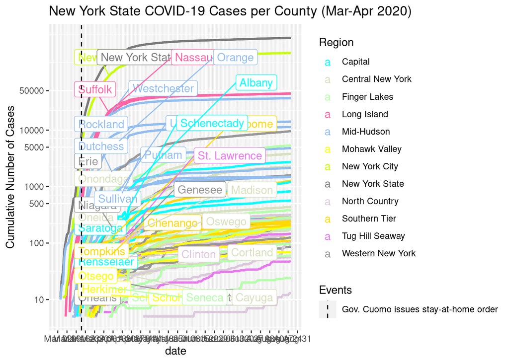

## Accessing RStudio Server on the IDEA Cluster

The IDEA Cluster provides five compute nodes (4x 48 cores, 1x 80 cores, 1x storage server)

- RCS credentials (via registration in class); email John Erickson for problems `erickj4@rpi.edu`
- RStudio, Jupyter, MATLAB, GPUs (on two nodes); lots of storage and computes
- Access via RPI physical network or VPN only

RStudio GUI Access:

- http://lp01.idea.rpi.edu/rstudio-ose/ or http://lp01.idea.rpi.edu/rstudio-ose-3/ (RStudio)
- Linux terminal accessible from within RStudio “Terminal” or via ssh (below)

Shared Data on Cluster:

- All idea_users have access to shared storage via `/data` (“data” in your home directories)
- Shell access to nodes: You must access “landing pad” first, then compute node:
- `ssh your_rcs@lp01.idea.rpi.edu` For example: `ssh erickj4@lp01.idea.rpi.edu`
- Then, `ssh` to the desired compute node, e.g.: `ssh idea-node-02`